# BSC | Assignment

Edgar Chacón (edgarpedro.chacon01@estudiant.upf.edu)

Last update: 04 July, 2024

# 0. Introduction

This file corresponds to the assignment asked for the application to the “Computational Biology Group” at the Barcelona Supercomputing Center (**BSC**).  
This assignment consist of the following tasks:

1. Download The PDB files
2. Install frustratometeR
3. Calculate single residue frustration for all PDBs
4. Calculate a histogram of frustration per residue for all PDBs
5. Calculate the frequency of amino acids in all PDBs

**NOTE**: Absolute paths in this R markdown may not work properly for others; adjust if necessary.

## 0.1. Libraries

Libraries used in this R markdown.

```r
# ---------------------------------------------------------------------LIBRARIES

invisible(lapply(c("usethis", "devtools", "reticulate", "ggplot2", "dplyr"), library, character.only = TRUE))

devtools::install_github("proteinphysiologylab/frustratometeR")

library(frustratometeR)
```

Modeller had to be installed previously.  
Specific information about dependencies installed in order to run `frustratometeR` are in the “Install frustratometeR” section.

# 1. Download The PDB files

To download the corresponding PDB files associated with the PDB IDs listed in the file List_100_PDBs, first I had to extract those IDs from the list.

```r
# -------------------------------------------------------------PDB ID EXTRACTION

pdb_list <- read.table("./List_100_PDBs", header = TRUE)
pdb_ids <- pdb_list$PdbID
pdb_ids
```

Then, generate the download URLs.

```r
# --------------------------------------------------------GENERATE DOWNLOAD URLS

base_url <- "https://files.rcsb.org/download/"
download_urls <- paste0(base_url, pdb_ids, ".pdb")
download_urls
```

And finally, use the `wget` command-line utility to download all the listed PDB files (100).

```r
# --------------------------------------------------------DOWNLOAD THE PDB FILES

pdb_folder <- "./PDBs"
if (!file.exists(pdb_folder)) {
  dir.create(pdb_folder, showWarnings = FALSE)
}

for (pdb_id in pdb_ids) {
  wget_command <- paste("wget", paste0("https://files.rcsb.org/download/", pdb_id, ".pdb"),
                        "-P", pdb_folder, "-nc --progress=bar:force:noscroll -q --show-progress")
  system(wget_command)
}

num_files <- system(paste("find", pdb_folder, "-name '*.pdb' | wc -l"), intern = TRUE)
cat(paste(num_files, "PDB files have been downloaded successfully.\n"))
```

```
## 100 PDB files have been downloaded successfully.
```

# 2. Install frustratometeR

To install `frustratometeR`, first I had to install all the necessary dependencies (System, Python and R Package dependencies).  
To do so, I first executed in terminal the script install_frustraR.sh obtained from the [GitHub page](https://github.com/proteinphysiologylab/frustratometeR.git) of the R packacge `frustratometeR`.

Then, I created a conda environment with python 3.9, where I installed `modeller` (modeller_10.5-1_amd64.deb) and set the following configuration for this R markdown:

```r
# --------------------------------------------------MODELLER CONFIGURATION (ENV)

use_python("/home/user/miniconda3/envs/frustratometeR/bin/python3")

use_condaenv(condaenv = "frustratometeR", conda = "/home/user/miniconda3/condabin/conda")

Sys.setenv(RETICULATE_PYTHON = "/home/user/miniconda3/envs/frustratometeR/bin/python3")

reticulate::py_config()
```

```
## python:         /home/user/miniconda3/envs/frustratometeR/bin/python3
## libpython:      /home/user/miniconda3/envs/frustratometeR/lib/libpython3.9.so
## pythonhome:     /home/user/miniconda3/envs/frustratometeR:/home/user/miniconda3/envs/frustratometeR
## version:        3.9.19 (main, May  6 2024, 19:43:03)  [GCC 11.2.0]
## numpy:          /home/user/miniconda3/envs/frustratometeR/lib/python3.9/site-packages/numpy
## numpy_version:  2.0.0
##
## NOTE: Python version was forced by RETICULATE_PYTHON
```

To check if `modeller` actually works, I used the following python code:

```python
# ------------------------------------------CHECK MODELLER INSTALLATION {python}

try:
    from modeller import *
    print("Modeller is installed and can be imported successfully.")
except ImportError as e:
    print("ImportError:", e)
```

```
## Modeller is installed and can be imported successfully.
```

This allowed me to run the `frustratometeR` code on the next section “Calculate single residue frustration for all PDBs” and obtain the desired results.

# 3. Calculate single residue frustration for all PDBs

To calculate the single residue frustrations for each PDB file, first I created a `RESULTS folder` where the output files will be stored.  
Also, I checked which chains were of my interest for the analysis looking at the chains specified on the file List_100_PDBs.

```r
# ---------------------------------------------RESULTS FOLDER & CHAIN DEFINITION

results_folder <- "/home/rstudio/myfiles/BSC_Assignment/BSC_Assignment/RESULTS/"
if (!file.exists(results_folder)) {
  dir.create(results_folder, showWarnings = FALSE)
}

# NOTE: Adjust the absolute path if necessary.

pdb_chain <- unique(pdb_list$Chain)
```

All chains of interest in the PDB list resulted in the same one: “A”.  
So, I set that value (`pdb_chain`) as the desired chain on the following code that will calculate all single residue frustrations for all PDBs found in the `PDBs folder`.

```r
# --------------------------------------------------------CALCULATE FRUSTRATIONS

dir_frustration(PdbsDir = "/home/rstudio/myfiles/BSC_Assignment/BSC_Assignment/PDBs/",
                OrderList = NULL,
                Chain = pdb_chain,
                Mode = "singleresidue",
                ResultsDir = results_folder)

# NOTE: Adjust the absolute path if necessary.
```

All frustration values were successfully generated and stored on the `RESULTS folder`.

# 4. Calculate a histogram of frustration per residue for all PDBs

To generate a histogram showing frustration per residue for all PDBs, I had to take into account that because the analysis was derived from 100 PDB files, I had to firstly combine the data.

To do so, I loaded the data obtained when I calculated the frustration of all PDBs, and combined all the resulting data into a single data frame.

```r
# --------------------------------------------------------------FRUSTRATION DATA

data_list <- list()

for (pdb_id in pdb_ids) {

  file_path <- file.path(results_folder, paste0(pdb_id, "_", pdb_chain, ".done/FrustrationData/", pdb_id, "_", pdb_chain, ".pdb_singleresidue"))

  if (file.exists(file_path)) {
    data <- read.table(file_path, header = TRUE, stringsAsFactors = FALSE)

    data_list[[length(data_list) + 1]] <- data
  } else {
    message(paste("File not found:", file_path))
  }
}

combined_data <- bind_rows(data_list)
```

And then I generated the histogram itself.

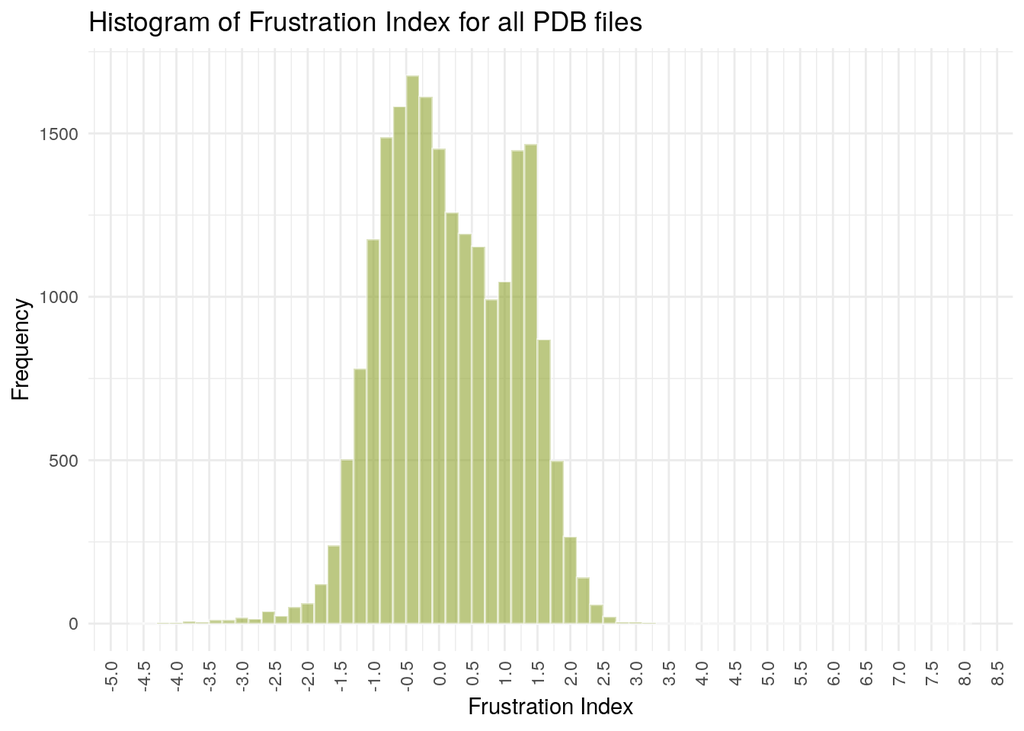

Histogram of Frustration Index for all PDB files. This plot shows the frequency of the Frustration Indexes found in all the PDBs from the list.

```r
# ---------------------------------------------------FRUSTRATION INDEX HISTOGRAM

ggplot(combined_data, aes(x = FrstIndex)) +
  geom_histogram(binwidth = 0.2, fill = my_green, alpha = 0.6, color = alpha("white", 0.5)) +
  labs(title = "Histogram of Frustration Index for all PDB files",
       x = "Frustration Index",
       y = "Frequency") +
  scale_x_continuous(breaks = seq(floor(min(combined_data$FrstIndex)), ceiling(max(combined_data$FrstIndex)), by = 0.5)) +
  theme_minimal() +
  theme(axis.text.x = element_text(angle = 90, vjust = 0.5, hjust = 1))
```

Because I wasn’t sure that the previous plot was the histogram that I had to do, I tried to generate another histogram showing the frustration per residue.

To do that, I had to aggregate the data calculating the mean frustration score for each residue.

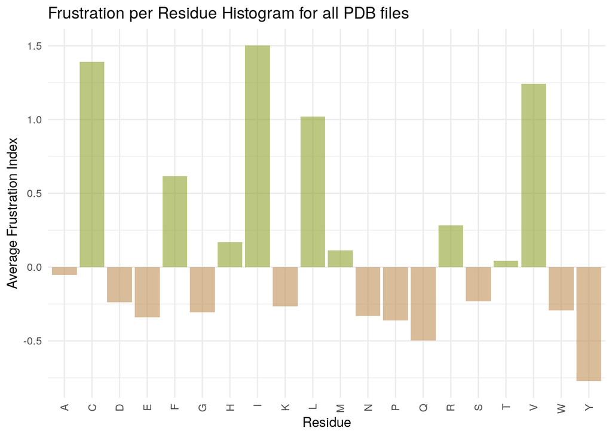

Frustration per residue histogram for all PDB files. This plot shows the Average Frustration Index for each of the 20 amino acids across all the PDBs from the list.

```r
# ---------------------------------------------FRUSTRATION PER RESIDUE HISTOGRAM

frustration_summary <- combined_data %>%
  group_by(AA) %>%
  summarize(avg_frustration = mean(FrstIndex))

frustration_summary$color <- ifelse(frustration_summary$avg_frustration >= 0, my_green, my_orange)

ggplot(frustration_summary, aes(x = AA, y = avg_frustration, fill = color)) +
  geom_bar(stat = "identity", alpha = 0.6) +
  labs(x = "Residue", y = "Average Frustration Index", title = "Frustration per Residue Histogram for all PDB files") +
  scale_fill_identity() +
  theme_minimal() +
  theme(axis.text.x = element_text(angle = 90, vjust = 0.5, hjust = 1))
```

Finally, as suggested by Gonzalo, I add here the code I previously used to generate a histogram for the frustration results of each one of the PDB files individually.

First, I created the `PLOTS folder` to store all 100 plots.

```r
# ------------------------------------------------------------------PLOTS FOLDER

plots_folder <- "./PLOTS/"
if (!file.exists(plots_folder)) {
  dir.create(plots_folder, showWarnings = FALSE)
}
```

Then generated and stored each one of the 100 individual frustration index histograms.

```r
# ---------------------------------------INDIVIDUAL FRUSTRATION INDEX HISTOGRAMS

for (pdb_id in pdb_ids) {

  file_path <- file.path(results_folder, paste0(pdb_id, "_", pdb_chain, ".done/FrustrationData/", pdb_id, "_", pdb_chain, ".pdb_singleresidue"))

  if (file.exists(file_path)) {

    individual_data <- read.table(file_path, header = TRUE, stringsAsFactors = FALSE)

    individual_plot <- ggplot(individual_data, aes(x = FrstIndex)) +
      geom_histogram(binwidth = 0.1, fill = my_green, alpha = 0.6, color = alpha("white", 0.5)) +
      labs(title = paste("Histogram of Frustration Index for", pdb_id),
           x = "Frustration Index",
           y = "Frequency") +
      scale_x_continuous(breaks = seq(floor(min(combined_data$FrstIndex)),
                                      ceiling(max(combined_data$FrstIndex)), by = 0.5)) +
      theme_minimal() +
      theme(axis.text.x = element_text(angle = 90, vjust = 0.5, hjust = 1))

    output_file <- file.path(plots_folder, paste0(pdb_id, "_", pdb_chain, "_FrstIndex_Histogram.jpg"))

    ggsave(output_file, plot = individual_plot, width = 8, height = 6)

  } else {
    message(paste("File not found:", file_path))
  }
}
```

All individual frustration index histograms can be accessed in the `PLOTS folder`.

# 5. Calculate the frequency of amino acids in all PDBs

To calculate the frequency of amino acids in all 100 PDB files, I assumed that only the chains specified in the file List_100_PDBs were the ones of interest (Ignoring other possible chains being in some PDBs).  
Therefore, to save resources, instead of starting from scratch with a count of amino acids extracted from the PDB files (which is too computationally demanding in terms of execution time), I decided to utilize the data resulting from the calculation of frustrations per single residue, which I already had combined.

Then plotted the histogram of amino acid frequencies.

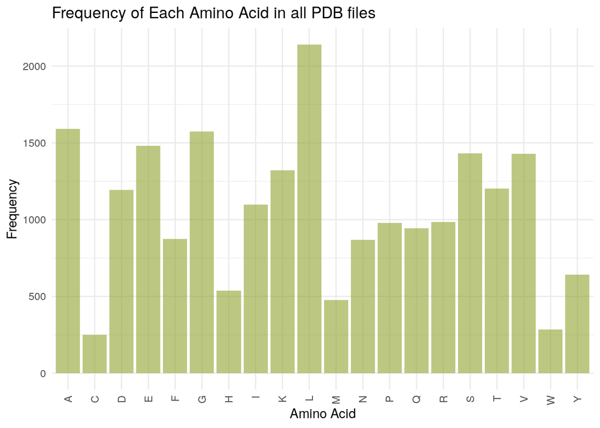

Frequency of each Amino Acid in all PDB files. This plot shows the frequency of the 20 amino acids across all the PDBs from the list.

```r
# ------------------------------------------------AMINO ACID FREQUENCY HISTOGRAM

aa_counts <- combined_data %>%
  count(AA) %>%
  arrange(desc(n))

ggplot(aa_counts, aes(x = AA, y = n)) +
  geom_bar(stat = "identity", fill = my_green, alpha = 0.6) +
  labs(x = "Amino Acid", y = "Frequency", title = "Frequency of Each Amino Acid in all PDB files") +
  theme_minimal() +
  theme(axis.text.x = element_text(angle = 90, vjust = 0.5, hjust = 1))
```

# Session info

R version 4.3.2 (2023-10-31) Platform: x86_64-pc-linux-gnu (64-bit) Running under: Ubuntu 22.04.3 LTS

Matrix products: default BLAS: /usr/lib/x86_64-linux-gnu/openblas-pthread/libblas.so.3 LAPACK: /usr/lib/x86_64-linux-gnu/openblas-pthread/libopenblasp-r0.3.20.so; LAPACK version 3.10.0

locale: [1] LC_CTYPE=en_US.UTF-8 LC_NUMERIC=C  
[3] LC_TIME=en_US.UTF-8 LC_COLLATE=en_US.UTF-8  
[5] LC_MONETARY=en_US.UTF-8 LC_MESSAGES=en_US.UTF-8  
[7] LC_PAPER=en_US.UTF-8 LC_NAME=C  
[9] LC_ADDRESS=C LC_TELEPHONE=C  
[11] LC_MEASUREMENT=en_US.UTF-8 LC_IDENTIFICATION=C

time zone: Etc/UTC tzcode source: system (glibc)

attached base packages: [1] stats graphics grDevices utils datasets methods base

other attached packages: [1] frustratometeR_0.1.0 dplyr_1.1.4 ggplot2_3.5.1  
[4] reticulate_1.38.0 devtools_2.4.5 usethis_2.2.3